# Visium preprocessing tutorial

This tutorial demonstrates how to load a 10x Genomics Visium dataset and transform its spot-level measurements into a regular spatial grid for downstream SQUALL analysis.

## 1. Load the Visium data

Prepare a Visium output directory and a gene-token mapping file, then load the count matrix, spatial coordinates, scale factors, and H&E image. Replace the example paths below with paths relative to your working directory.

```
(AnnData object with n_obs × n_vars = 4898 × 15757
     var: 'gene_ids_x', 'feature_types', 'genome', 'symbol_x', 'gene_ids_y', 'symbol_y',
                     in_tissue  array_row  array_col  pxl_row_in_fullres  \
 barcode
 ACGCCTGACACGCGCT-1          1        0.0        0.0              4650.0
 TACCGATCCAACACTT-1          1        1.0        1.0              4887.0
 ATTAAAGCGGACGAGC-1          1        0.0        2.0              4651.0
 GATAAGGGACGATTAG-1          1        1.0        3.0              4888.0
 GTGCAAATCACCAATA-1          1        0.0        4.0              4653.0
 ...                       ...        ...        ...                 ...
 GAACGTTTGTATCCAC-1          1       77.0      123.0             22941.0
 ATTGAATTCCCTGTAG-1          1       76.0      124.0             22706.0
 TACCTCACCAATTGTA-1          1       77.0      125.0             22943.0
 AGTCGAATTAGCGTAA-1          1       76.0      126.0             22707.0
 TTGAAGTGCATCTACA-1          1       77.0      127.0             22944.0

                     pxl_col_in_fullres
 barcode
 ACGCCTGACACGCGCT-1             12203.0
 TACCGATCCAACACTT-1             12338.0
 ATTAAAGCGGACGAGC-1             12475.0
 GATAAGGGACGATTAG-1             12609.0
 GTGCAAATCACCAATA-1             12747.0
 ...                                ...
 GAACGTTTGTATCCAC-1             28802.0
 ATTGAATTCCCTGTAG-1             28939.0
 TACCTCACCAATTGTA-1             29074.0
 AGTCGAATTAGCGTAA-1             29211.0
 TTGAAGTGCATCTACA-1             29345.0

 [4992 rows x 5 columns],
    tissue_hires_scalef  tissue_lowres_scalef  fiducial_diameter_fullres  \
 0             0.048109              0.014433                   285.1934

    spot_diameter_fullres
 0               176.5483  )
```

[figure not shown]

```python
from Visium import fileReader,Processer
import matplotlib.pyplot as plt
Reader=fileReader()
Reader.read_all(folder_path="data/Visium_Human_Breast_Cancer",gene_token="data/gene_token_homologs.csv",method="binary",key="symbol")
plt.imshow(Reader.raw_he)
Reader.adata , Reader.tissue_position_list , Reader.scaleJson
```

## 2. Initialize the processor

Create a `Processer` instance with a target grid size of 224 and standardize the Visium tissue-position table.

```python
processer=Processer(Reader,224)
processer.process_tpl()
processer.tissue_position_list
```

| barcode | in_tissue | spot_y | spot_x | pxl_y_fullres | pxl_x_fullres | pxl_y_hires | pxl_x_hires | top_left_before | top_left_after |
| --- | --- | --- | --- | --- | --- | --- | --- | --- | --- |
| ACGCCTGACACGCGCT-1 | 1 | 0.0 | 0.0 | 4650.0 | 12203.0 | 223.708264 | 587.077837 | None | None |
| TACCGATCCAACACTT-1 | 1 | 1.0 | 1.0 | 4887.0 | 12338.0 | 235.110169 | 593.572593 | None | None |
| ATTAAAGCGGACGAGC-1 | 1 | 0.0 | 2.0 | 4651.0 | 12475.0 | 223.756373 | 600.163567 | None | None |
| GATAAGGGACGATTAG-1 | 1 | 1.0 | 3.0 | 4888.0 | 12609.0 | 235.158278 | 606.610214 | None | None |
| GTGCAAATCACCAATA-1 | 1 | 0.0 | 4.0 | 4653.0 | 12747.0 | 223.852592 | 613.249298 | None | None |
| ... | ... | ... | ... | ... | ... | ... | ... | ... | ... |
| GAACGTTTGTATCCAC-1 | 1 | 77.0 | 123.0 | 22941.0 | 28802.0 | 1103.675543 | 1385.644174 | None | None |
| ATTGAATTCCCTGTAG-1 | 1 | 76.0 | 124.0 | 22706.0 | 28939.0 | 1092.369857 | 1392.235148 | None | None |
| TACCTCACCAATTGTA-1 | 1 | 77.0 | 125.0 | 22943.0 | 29074.0 | 1103.771762 | 1398.729904 | None | None |
| AGTCGAATTAGCGTAA-1 | 1 | 76.0 | 126.0 | 22707.0 | 29211.0 | 1092.417966 | 1405.320879 | None | None |
| TTGAAGTGCATCTACA-1 | 1 | 77.0 | 127.0 | 22944.0 | 29345.0 | 1103.819871 | 1411.767526 | None | None |

4992 rows × 9 columns

## 3. Align spots to the target grid

Round the transformed spot coordinates so that every observed spot can be assigned to a reproducible grid location.

```python
processer.round_spot()
processer.final_tpl
```

| barcode | in_tissue | spot_y | spot_x | tl_x | tl_y |
| --- | --- | --- | --- | --- | --- |
| ACGCCTGACACGCGCT-1 | 1 | 0.0 | 0.0 | 4 | 0 |
| TACCGATCCAACACTT-1 | 1 | 1.0 | 1.0 | 12 | 12 |
| ATTAAAGCGGACGAGC-1 | 1 | 0.0 | 2.0 | 16 | 0 |
| GATAAGGGACGATTAG-1 | 1 | 1.0 | 3.0 | 24 | 12 |
| GTGCAAATCACCAATA-1 | 1 | 0.0 | 4.0 | 32 | 0 |
| ... | ... | ... | ... | ... | ... |
| GAACGTTTGTATCCAC-1 | 1 | 77.0 | 123.0 | 804 | 880 |
| ATTGAATTCCCTGTAG-1 | 1 | 76.0 | 124.0 | 808 | 872 |
| TACCTCACCAATTGTA-1 | 1 | 77.0 | 125.0 | 816 | 880 |
| AGTCGAATTAGCGTAA-1 | 1 | 76.0 | 126.0 | 824 | 872 |
| TTGAAGTGCATCTACA-1 | 1 | 77.0 | 127.0 | 828 | 880 |

4992 rows × 5 columns

## 4. Generate and map the spatial grid

Generate the regular grid and map the observed tissue spots onto it. The resulting table links grid positions with their source Visium barcodes.

```python
processer.generate_grid()
processer.map_tissue()
processer.tissue_grid
```

| index | tl_xn | tl_yn | in_tissue | position | barcode_55 | spot_x | spot_y |
| --- | --- | --- | --- | --- | --- | --- | --- |
| s_004_0_0-n | 0.0 | 0.0 | 1.0 | s_004_0_0-n | 0 | 0.0 | 0.0 |
| s_004_4_0-n | 4.0 | 0.0 | 1.0 | s_004_4_0-n | 0 | 1.0 | 0.0 |
| s_004_8_0-n | 8.0 | 0.0 | 1.0 | s_004_8_0-n | 0 | 2.0 | 0.0 |
| s_004_12_0-n | 12.0 | 0.0 | 1.0 | s_004_12_0-n | 0 | 3.0 | 0.0 |
| s_004_16_0-n | 16.0 | 0.0 | 1.0 | s_004_16_0-n | TACCGATCCAACACTT-1 | 4.0 | 0.0 |
| ... | ... | ... | ... | ... | ... | ... | ... |
| s_004_744_-4-n | NaN | NaN | 0.0 | NaN | new | NaN | NaN |
| s_004_756_-4-n | NaN | NaN | 0.0 | NaN | new | NaN | NaN |
| s_004_772_-4-n | NaN | NaN | 0.0 | NaN | new | NaN | NaN |
| s_004_784_-4-n | NaN | NaN | 0.0 | NaN | new | NaN | NaN |
| s_004_796_-4-n | NaN | NaN | 0.0 | NaN | new | NaN | NaN |

50686 rows × 7 columns

## 5. Crop the histology image

Crop the H&E image to the spatial region covered by the generated grid. The two panels compare the original crop and the processed crop.

```
<object>
```

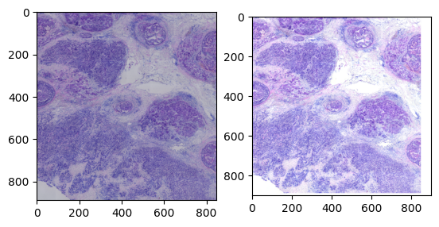

```python
_,_,_,_,raw_crop_he,crop_he=processer.crop_img()
fig,axs=plt.subplots(1,2)
axs[0].imshow(raw_crop_he)
axs[1].imshow(crop_he)
```

## 6. Identify grid locations supported by observed spots

Compute the grid locations associated with measured Visium spots before interpolation.

```python
processer.find_avg_grid()
processer.avg_grid
```

| index | tl_xn | tl_yn | in_tissue | position | barcode_55 | spot_x | spot_y |
| --- | --- | --- | --- | --- | --- | --- | --- |
| s_004_16_0-n | 16.0 | 0.0 | 1.0 | s_004_16_0-n | TACCGATCCAACACTT-1 | 4.0 | 0.0 |
| s_004_20_0-n | 20.0 | 0.0 | 1.0 | s_004_20_0-n | TACCGATCCAACACTT-1 | 5.0 | 0.0 |
| s_004_24_0-n | 24.0 | 0.0 | 1.0 | s_004_24_0-n | TACCGATCCAACACTT-1 | 6.0 | 0.0 |
| s_004_28_0-n | 28.0 | 0.0 | 1.0 | s_004_28_0-n | GATAAGGGACGATTAG-1 | 7.0 | 0.0 |
| s_004_32_0-n | 32.0 | 0.0 | 1.0 | s_004_32_0-n | GATAAGGGACGATTAG-1 | 8.0 | 0.0 |
| ... | ... | ... | ... | ... | ... | ... | ... |
| s_004_696_896-n | 696.0 | 896.0 | 1.0 | s_004_696_896-n | ATCTCATAAACCTACC-1 | 174.0 | 224.0 |
| s_004_700_896-n | 700.0 | 896.0 | 1.0 | s_004_700_896-n | TTGCAGGTCATGAAGT-1 | 175.0 | 224.0 |
| s_004_704_896-n | 704.0 | 896.0 | 1.0 | s_004_704_896-n | TTGCAGGTCATGAAGT-1 | 176.0 | 224.0 |
| s_004_708_896-n | 708.0 | 896.0 | 1.0 | s_004_708_896-n | TTGCAGGTCATGAAGT-1 | 177.0 | 224.0 |
| s_004_712_896-n | 712.0 | 896.0 | 1.0 | s_004_712_896-n | TTGCAGGTCATGAAGT-1 | 178.0 | 224.0 |

45458 rows × 7 columns

## 7. Insert interpolated grid locations

Add the missing tissue-grid positions required for a dense spatial representation.

```python
processer.insert_grid()
processer.interp_grid
```

| index | tl_xn | tl_yn | in_tissue | position | barcode_55 | spot_x | spot_y |
| --- | --- | --- | --- | --- | --- | --- | --- |
| s_004_0_0-n | 0.0 | 0.0 | 1.0 | s_004_0_0-n | 0 | 0.0 | 0.0 |
| s_004_4_0-n | 4.0 | 0.0 | 1.0 | s_004_4_0-n | 0 | 1.0 | 0.0 |
| s_004_8_0-n | 8.0 | 0.0 | 1.0 | s_004_8_0-n | 0 | 2.0 | 0.0 |
| s_004_12_0-n | 12.0 | 0.0 | 1.0 | s_004_12_0-n | 0 | 3.0 | 0.0 |
| s_004_52_0-n | 52.0 | 0.0 | 1.0 | s_004_52_0-n | 0 | 13.0 | 0.0 |
| ... | ... | ... | ... | ... | ... | ... | ... |
| s_004_880_896-n | 880.0 | 896.0 | 1.0 | NaN | new | 220.0 | 224.0 |
| s_004_884_896-n | 884.0 | 896.0 | 1.0 | NaN | new | 221.0 | 224.0 |
| s_004_888_896-n | 888.0 | 896.0 | 1.0 | NaN | new | 222.0 | 224.0 |
| s_004_892_896-n | 892.0 | 896.0 | 1.0 | NaN | new | 223.0 | 224.0 |
| s_004_896_896-n | 896.0 | 896.0 | 1.0 | NaN | new | 224.0 | 224.0 |

3839 rows × 7 columns

## 8. Build the final AnnData object

Combine observed and interpolated grid locations with the gene-expression matrix. The resulting AnnData object is ready for downstream SQUALL workflows.

```python
processer.concat_adata()
processer.fnl_adata
```

```
AnnData object with n_obs × n_vars = 50686 × 15757
    var: 'gene_ids_x', 'feature_types', 'genome', 'symbol_x', 'gene_ids_y', 'symbol_y'
```